# TelcoChurn_Analysis

Parita Danecha

1/9/2022

## Install package

```r
install.packages("randomForest")
install.packages("caret")
install.packages("ggplot2")
install.packages("gridExtra")
```

## Load libraries

```r
library(ggplot2)
library(gridExtra)
library(randomForest)
library(caret)
```

## Load the dataset

```r
churn<-read.csv("C:/Users/HP/Documents/Predictive Analysis/Churn.csv")
head(churn)
```

```
##   customerID gender SeniorCitizen Partner Dependents tenure PhoneService
## 1 7590-VHVEG Female             0     Yes         No      1           No
## 2 5575-GNVDE   Male             0      No         No     34          Yes
## 3 3668-QPYBK   Male             0      No         No      2          Yes
## 4 7795-CFOCW   Male             0      No         No     45           No
## 5 9237-HQITU Female             0      No         No      2          Yes
## 6 9305-CDSKC Female             0      No         No      8          Yes
##      MultipleLines InternetService OnlineSecurity OnlineBackup DeviceProtection
## 1 No phone service             DSL             No          Yes               No
## 2               No             DSL            Yes           No              Yes
## 3               No             DSL            Yes          Yes               No
## 4 No phone service             DSL            Yes           No              Yes
## 5               No     Fiber optic             No           No               No
## 6              Yes     Fiber optic             No           No              Yes
##   TechSupport StreamingTV StreamingMovies       Contract PaperlessBilling
## 1          No          No              No Month-to-month              Yes
## 2          No          No              No       One year               No
## 3          No          No              No Month-to-month              Yes
## 4         Yes          No              No       One year               No
## 5          No          No              No Month-to-month              Yes
## 6          No         Yes             Yes Month-to-month              Yes
##               PaymentMethod MonthlyCharges TotalCharges Churn
## 1          Electronic check          29.85        29.85    No
## 2              Mailed check          56.95      1889.50    No
## 3              Mailed check          53.85       108.15   Yes
## 4 Bank transfer (automatic)          42.30      1840.75    No
## 5          Electronic check          70.70       151.65   Yes
## 6          Electronic check          99.65       820.50   Yes
```

### 1. How many customers churn vs no churn?

```r
table(churn$Churn)
```

```
##
##   No  Yes
## 5174 1869
```

- From the above result, we can see that customers churn = 1869, no churn = 5174

### 2. Does the gender of customer have an influence on churn ?

```r
table(churn$gender)
```

```
##
## Female   Male
##   3488   3555
```

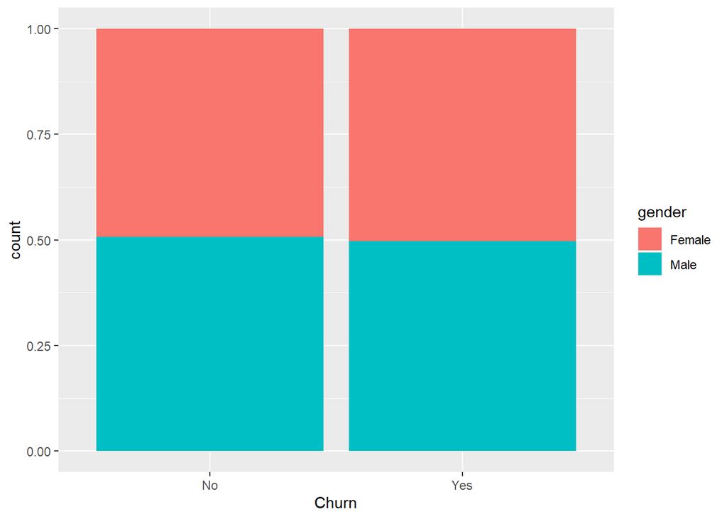

```r
plot_gender <- ggplot(data=churn)+geom_bar(mapping = aes(x=Churn, fill=gender), position="fill")
plot_gender
```

- We can see that gender doesn’t have any influence on churn

### 3. Does the InternetService , TechSupport, .have an influence on Churn ?

InternetService:

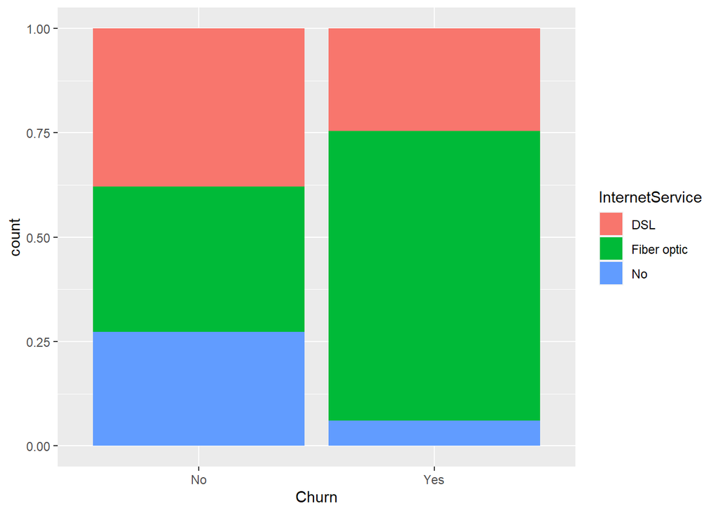

```r
plot_InternetService <- ggplot(data=churn)+geom_bar(mapping = aes(x=Churn, fill=InternetService), position="fill")
plot_InternetService
```

- People using Fiber optic has more tendency to leave the company as it might be some technical issue in Fiber optic Internet service.

TechSupport:

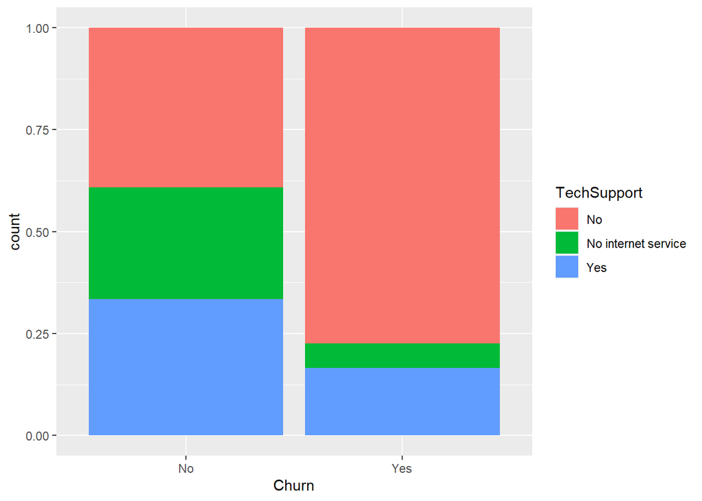

```r
plot_TechSupport <- ggplot(data=churn)+geom_bar(mapping = aes(x=Churn, fill=TechSupport), position="fill")
plot_TechSupport
```

- No tech support leads to increase in Churn rate.

### 4. Does the TotalCharges have an influence on Churn ?

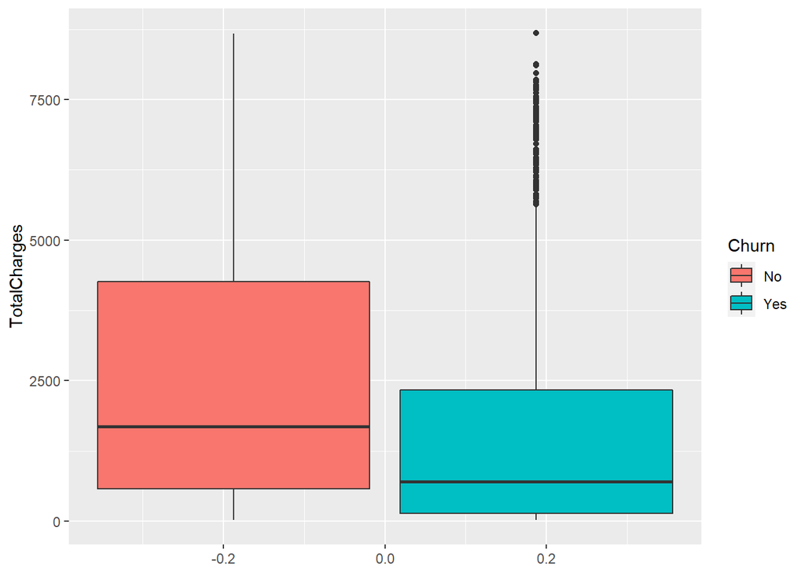

```r
ggplot(data=churn)+geom_boxplot(mapping = aes(y= TotalCharges, fill = Churn))
```

- Looking at the plot, we can say that people left the company are less affected by total charge as median of Churn=“Yes” is lower than the one with “No”.

### 5. What is tenure ? How is it linked to Churn ?

- Tenure is the duration of time an employee has worked for in the company.

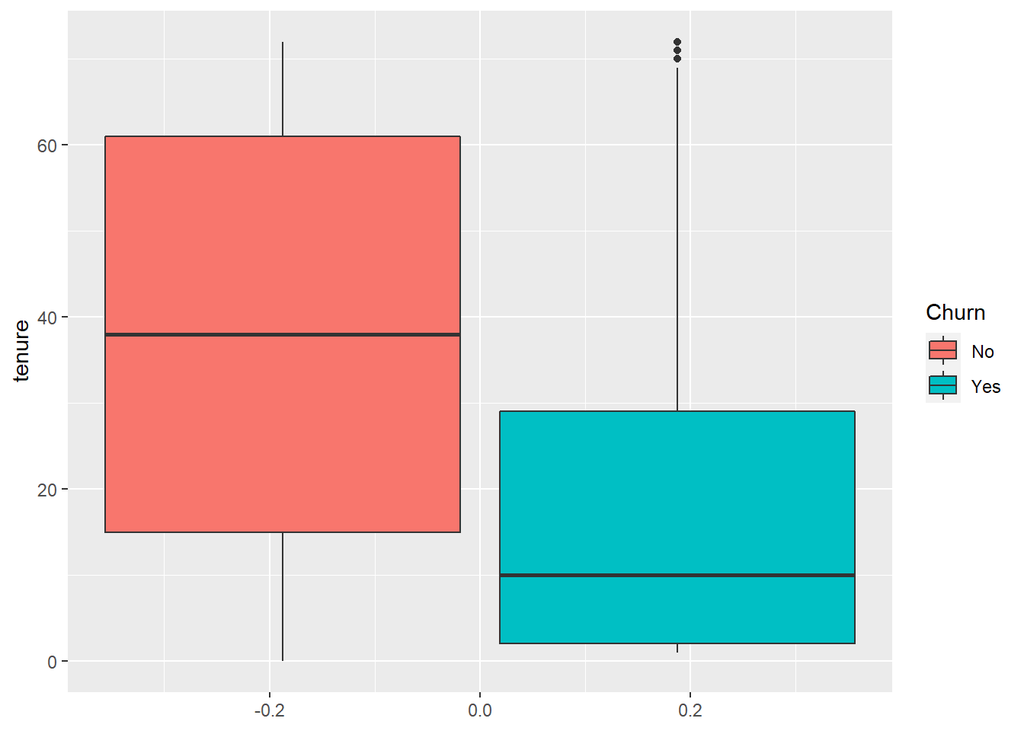

```r
ggplot(data=churn)+geom_boxplot(mapping = aes(y= tenure, fill = Churn))
```

- The more is the tenure, the less chances of customer churns. Here, people having around 10 months of tenure left the company.

### 6. Which key reasons have probably caused the loss of customers.

To find out this, let’s compare graphs of other variables linked to Churn.

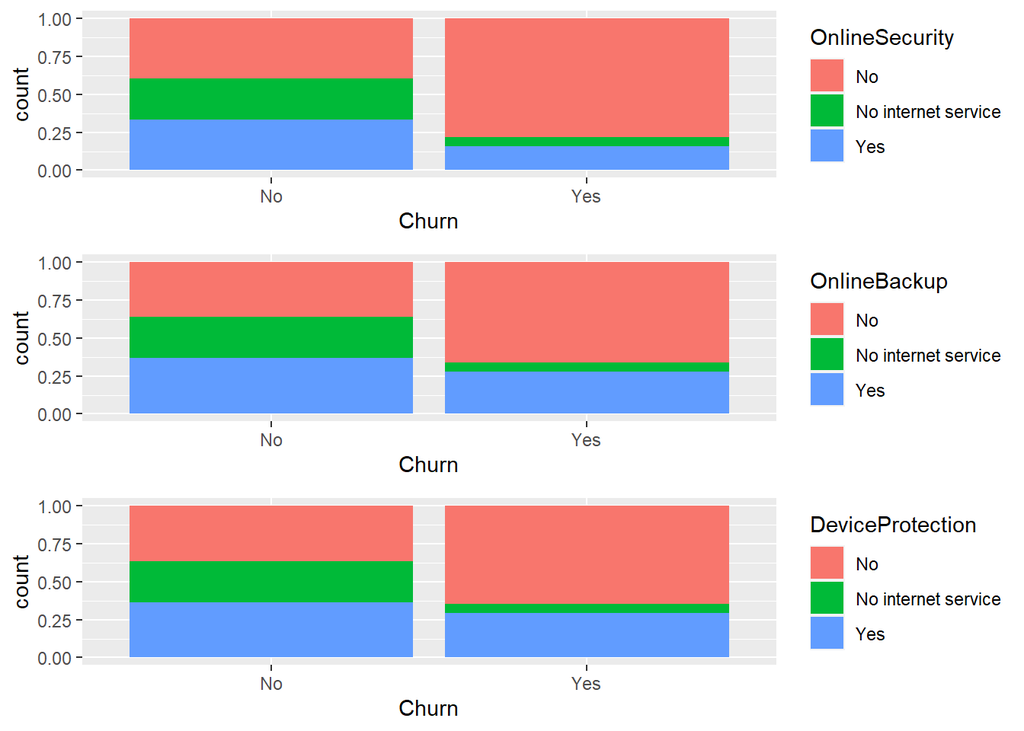

```r
plot_SeniorCitizen <- ggplot(data=churn)+geom_bar(mapping = aes(x=Churn, fill=SeniorCitizen), position="fill")
plot_OnlineSecurity <- ggplot(data=churn)+geom_bar(mapping = aes(x=Churn, fill=OnlineSecurity), position="fill")
plot_OnlineBackup <- ggplot(data=churn)+geom_bar(mapping = aes(x=Churn, fill=OnlineBackup), position="fill")
plot_DeviceProtection <- ggplot(data=churn)+geom_bar(mapping = aes(x=Churn, fill=DeviceProtection), position="fill")

grid.arrange(plot_OnlineSecurity, plot_OnlineBackup, plot_DeviceProtection, nrow=3)
```

- We can see from the plots that Customers having No Online Security, Online Backup, and Device Protection, left the company.

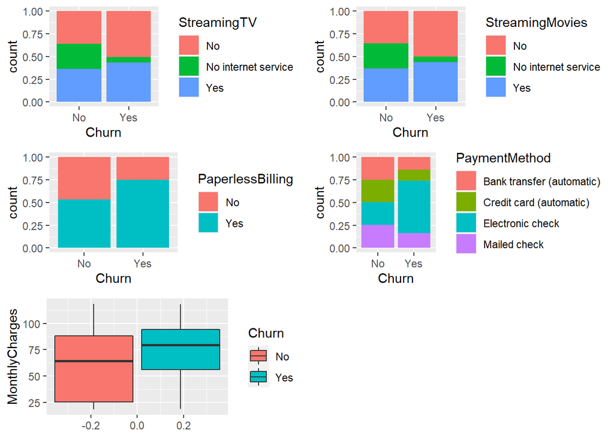

```r
plot_StreamingTV <- ggplot(data=churn)+geom_bar(mapping = aes(x=Churn, fill=StreamingTV), position="fill")
plot_StreamingMovies <- ggplot(data=churn)+geom_bar(mapping = aes(x=Churn, fill=StreamingMovies), position="fill")
plot_PaymentMethod <- ggplot(data=churn)+geom_bar(mapping = aes(x=Churn, fill=PaymentMethod), position="fill")
plot_PaperlessBilling <- ggplot(data=churn)+geom_bar(mapping = aes(x=Churn, fill=PaperlessBilling), position="fill")
plot_MonthlyCharges <- ggplot(data=churn)+geom_boxplot(mapping = aes(y= MonthlyCharges, fill = Churn))

grid.arrange(plot_StreamingTV, plot_StreamingMovies, plot_PaperlessBilling, plot_PaymentMethod, plot_MonthlyCharges, nrow=3)
```

- Paperless billing and Customers with Payment method as electronic check, left the company.

## Analyze Dataset

Remove the column id which doesn’t influence the prediction

```r
churn<-churn[-1]
```

To check NA in features

```r
colSums(is.na(churn))
```

```
##           gender    SeniorCitizen          Partner       Dependents
##                0                0                0                0
##           tenure     PhoneService    MultipleLines  InternetService
##                0                0                0                0
##   OnlineSecurity     OnlineBackup DeviceProtection      TechSupport
##                0                0                0                0
##      StreamingTV  StreamingMovies         Contract PaperlessBilling
##                0                0                0                0
##    PaymentMethod   MonthlyCharges     TotalCharges            Churn
##                0                0               11                0
```

- Total Charge has 11 NA which we can ignore.

```r
churn <- na.omit(churn)
```

- Rows reduced from 7043 to 7032

Transform Churn into factor

```r
churn$Churn<-factor(churn$Churn,levels = c("No","Yes"),labels = c("0","1"))
```

Split the dataset in 2 parts : train and test. Take 80% of lines of dataset churn to create dataset train

```r
churn_train<-churn[1:5634,]
churn_test<-churn[5635:7043,]
```

## Model fit

```r
rf.churn=randomForest(Churn~ . ,data=churn_train)
```

## Prediction

```r
rfpredict_churn <- predict(rf.churn, churn_test)
confusionMatrix(rfpredict_churn, churn_test$Churn)
```

```
## Confusion Matrix and Statistics
##
##           Reference
## Prediction   0   1
##          0 917 186
##          1 104 191
##
##                Accuracy : 0.7926
##                  95% CI : (0.7703, 0.8135)
##     No Information Rate : 0.7303
##     P-Value [Acc > NIR] : 4.353e-08
##
##                   Kappa : 0.4346
##
##  Mcnemar's Test P-Value : 1.970e-06
##
##             Sensitivity : 0.8981
##             Specificity : 0.5066
##          Pos Pred Value : 0.8314
##          Neg Pred Value : 0.6475
##              Prevalence : 0.7303
##          Detection Rate : 0.6559
##    Detection Prevalence : 0.7890
##       Balanced Accuracy : 0.7024
##
##        'Positive' Class : 0
##
```